# Exercise 1

# Objectives

- View data
- Create histogram of oyster lengths
- Work in layers
- Facets

## About the data

This data was collected by the Guana Tolomato Matanzas National Estuarine Research Reserve as part of an oyster monitoring pilot project led by Head Biologist Pamela Marcum. A report with this information can be found [here](https://gtmnerr.org/wp-content/uploads/2018/10/2014-2016-GTM-oyster-monitoring.pdf).

We are going to use this data to visualize the distribution of oyster lengths within different regions of the GTMNERR as well as within harvest and non-harvest zones.

# A

1. What are the variables in `oysters`?

2. What class are the variables?

3. What are the unique regions in which this data was collected? (*Hint: check out the `unique()` function for help*)

4. When were these data collected? Explore the date variable.

# B

Next, create a histogram of oyster lengths for the whole dataset using the height measurements.

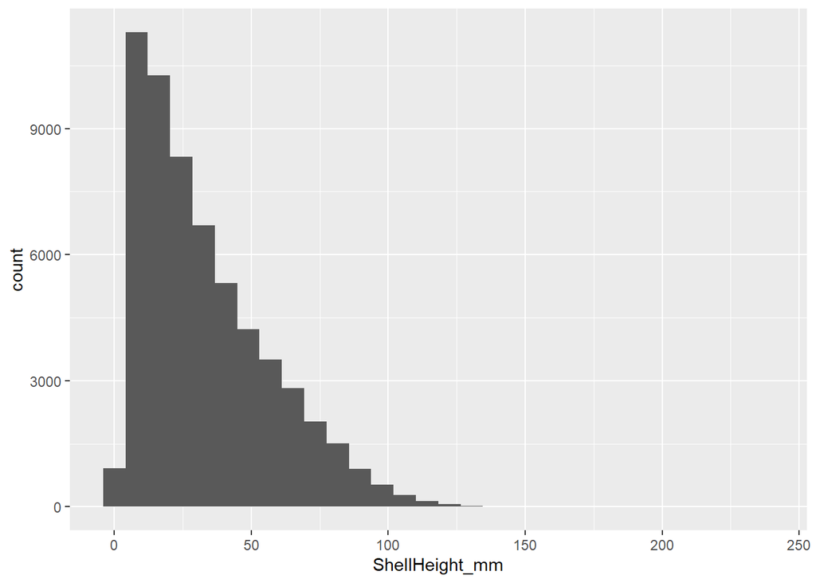

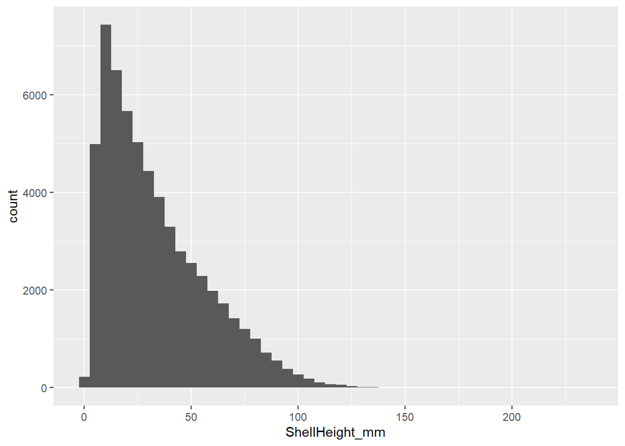

# C

Fishery-sized oysters (“harvestable”) must be three inches in length (76 mm). Let’s add a vertical line to the plot using `geom_vline` at 76mm for fishery-size.

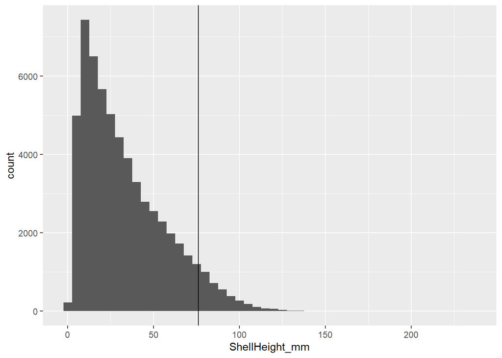

Excellent! Now, the upper limit of oyster spat (newly settled oysters) is 25mm. Let’s add a line on there for that, too, but make it a “dashed” linetype.

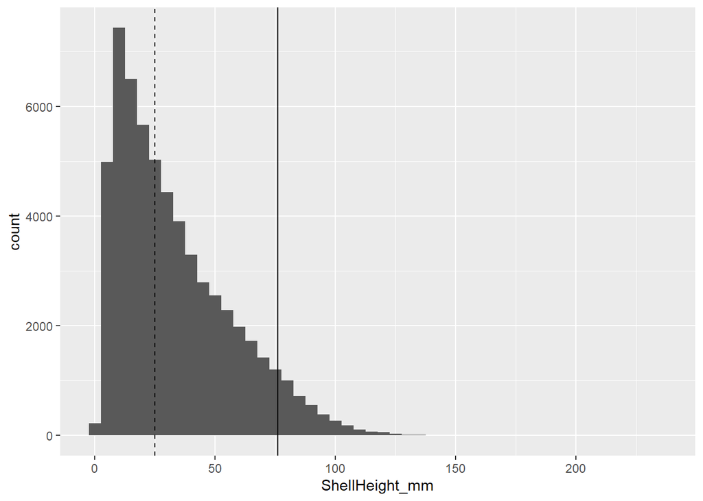

# D

Next, let’s look at how these oyster lengths look within and outside of harvest zones by filling the bars by the `Harvest` variable.

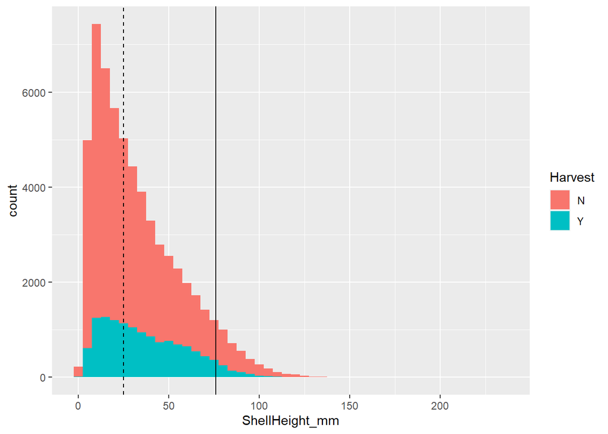

# E

Using facet_wrap, separate the harvest information into two separate plots

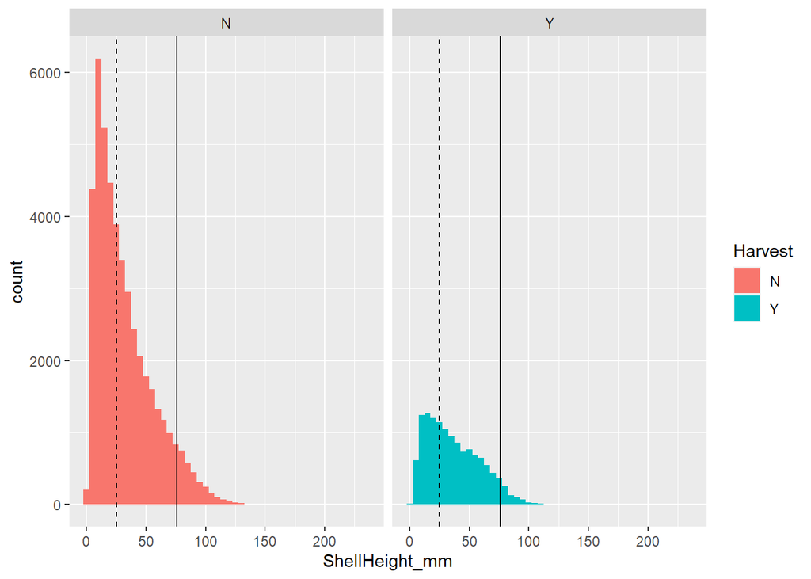

What are your observations of this data?